# Introduction à l'exploration intéractive de données avec Python et Pandas

Author: Alexandre Gramfort, Joseph Salmon

Objectif: Comprendre le contenu des données, la structure, les problèmes (données manquantes / aberrantes)

### Les données:

MovieLens 1M Data Set contient les notes attribuées à des films par des utilisateurs du site Movielens. Les données sont fournies, mais peuvent être trouvées, si besoin, à l'adresse: http://grouplens.org/datasets/movielens/

### Chargement de packages utiles

```python
import pandas as pd  #pour l'exploration de données
import numpy as np   #pour les operations numeriques (type Matlab)
```

### Lire les données "users" dans un DataFrame Pandas

```python
unames = ['user_id', 'gender', 'age', 'occupation', 'zip']
users = pd.read_table('ml-1m/users.dat', sep='::', header=None, names=unames, engine='python')
```

```python
users.head()
```

|  | user_id | gender | age | occupation | zip |
| --- | --- | --- | --- | --- | --- |
| 0 | 1 | F | 1 | 10 | 48067 |
| 1 | 2 | M | 56 | 16 | 70072 |
| 2 | 3 | M | 25 | 15 | 55117 |
| 3 | 4 | M | 45 | 7 | 02460 |
| 4 | 5 | M | 25 | 20 | 55455 |

### Lire les données "rating" dans un DataFrame Pandas

```python
rnames = ['user_id', 'movie_id', 'rating', 'timestamp']
ratings = pd.read_table('ml-1m/ratings.dat', sep='::', header=None, names=rnames, engine='python')
```

```python
ratings.head(10)
```

|  | user_id | movie_id | rating | timestamp |
| --- | --- | --- | --- | --- |
| 0 | 1 | 1193 | 5 | 978300760 |
| 1 | 1 | 661 | 3 | 978302109 |
| 2 | 1 | 914 | 3 | 978301968 |
| 3 | 1 | 3408 | 4 | 978300275 |
| 4 | 1 | 2355 | 5 | 978824291 |
| 5 | 1 | 1197 | 3 | 978302268 |
| 6 | 1 | 1287 | 5 | 978302039 |
| 7 | 1 | 2804 | 5 | 978300719 |
| 8 | 1 | 594 | 4 | 978302268 |
| 9 | 1 | 919 | 4 | 978301368 |

### Lire les données sur les films dans un Data Frame Pandas

```python
mnames = ['movie_id', 'title', 'genres']
movies = pd.read_table('ml-1m/movies.dat', sep='::', header=None, names=mnames, engine='python')
```

```python
movies.head(10)
```

|  | movie_id | title | genres |
| --- | --- | --- | --- |
| 0 | 1 | Toy Story (1995) | Animation\|Children's\|Comedy |
| 1 | 2 | Jumanji (1995) | Adventure\|Children's\|Fantasy |
| 2 | 3 | Grumpier Old Men (1995) | Comedy\|Romance |
| 3 | 4 | Waiting to Exhale (1995) | Comedy\|Drama |
| 4 | 5 | Father of the Bride Part II (1995) | Comedy |
| 5 | 6 | Heat (1995) | Action\|Crime\|Thriller |
| 6 | 7 | Sabrina (1995) | Comedy\|Romance |
| 7 | 8 | Tom and Huck (1995) | Adventure\|Children's |
| 8 | 9 | Sudden Death (1995) | Action |
| 9 | 10 | GoldenEye (1995) | Action\|Adventure\|Thriller |

### Fusion des données en un seul DataFrame

```python
data = pd.merge(pd.merge(ratings, users), movies)
```

```python
data.head() #head() permet de n'afficher que les premieres lignes pour la visualisation
```

|  | user_id | movie_id | rating | timestamp | gender | age | occupation | zip | title | genres |
| --- | --- | --- | --- | --- | --- | --- | --- | --- | --- | --- |
| 0 | 1 | 1193 | 5 | 978300760 | F | 1 | 10 | 48067 | One Flew Over the Cuckoo's Nest (1975) | Drama |
| 1 | 2 | 1193 | 5 | 978298413 | M | 56 | 16 | 70072 | One Flew Over the Cuckoo's Nest (1975) | Drama |
| 2 | 12 | 1193 | 4 | 978220179 | M | 25 | 12 | 32793 | One Flew Over the Cuckoo's Nest (1975) | Drama |
| 3 | 15 | 1193 | 4 | 978199279 | M | 25 | 7 | 22903 | One Flew Over the Cuckoo's Nest (1975) | Drama |
| 4 | 17 | 1193 | 5 | 978158471 | M | 50 | 1 | 95350 | One Flew Over the Cuckoo's Nest (1975) | Drama |

# Explorons !

### Question 1

Combien de films ont une note supérieure à 4.5 ? Existe-t-il une différence entre les hommes et les femmes?

```python
np.sum(data.rating > 4.5)
```

```
226310
```

```python
np.sum(data.rating[data.gender == 'F'] > 4.5)
```

```
58546
```

```python
np.sum(data.rating[data.gender == 'M'] > 4.5)
```

```
167764
```

Attention il vaut mieux regarder les proportions pour avoir une réponse pertinente:

```python
np.sum(data.rating[data.gender == 'F'] > 4.5) * 1.0 / np.sum(data.rating[data.gender == 'F']<6)
```

```
0.23756695341665315
```

```python
np.sum(data.rating[data.gender == 'M'] > 4.5) * 1.0 / np.sum(data.rating[data.gender == 'M']<6)
```

```
0.22256686066951545
```

### Question 2

Combien de films ont une note médiane au dessus de 4,5 parmis les hommes de plus de 30 ans? parmis les femmes de plus de 30 ans?

```python
np.sum(data[(data.gender == 'M') & (data.age >= 30)].groupby('movie_id', axis=0)['rating'].median() >= 4.5)
```

```
105
```

```python
np.sum(data[(data.gender == 'F') & (data.age >= 30)].groupby('movie_id', axis=0)['rating'].median() >= 4.5)
```

```
187
```

### Question 3

Quelles sont les films les plus populaires?

```python
data.groupby('movie_id', axis=0)['rating'].mean().nlargest(15)
```

```
movie_id
787     5.000000
989     5.000000
1830    5.000000
3172    5.000000
3233    5.000000
3280    5.000000
3382    5.000000
3607    5.000000
3656    5.000000
3881    5.000000
3245    4.800000
53      4.750000
2503    4.666667
2905    4.608696
2019    4.560510
Name: rating, dtype: float64
```

```python
data[data.movie_id == 787]
```

|  | user_id | movie_id | rating | timestamp | gender | age | occupation | zip | title | genres |
| --- | --- | --- | --- | --- | --- | --- | --- | --- | --- | --- |
| 965717 | 149 | 787 | 5 | 977325719 | M | 25 | 1 | 29205 | Gate of Heavenly Peace, The (1995) | Documentary |
| 965718 | 2825 | 787 | 5 | 972610193 | F | 25 | 20 | 94014 | Gate of Heavenly Peace, The (1995) | Documentary |
| 965719 | 2872 | 787 | 5 | 972423586 | M | 25 | 20 | 94014 | Gate of Heavenly Peace, The (1995) | Documentary |

Il y a un effet taille certain... ici seul trois personnes ont noté le meilleur film. Maintenant regardons ceux qui sont "suffisament" populaires:

```python
data.groupby('movie_id', axis=0)['rating'].count().head()
```

```
movie_id
1    2077
2     701
3     478
4     170
5     296
Name: rating, dtype: int64
```

```python
data2 = pd.concat([data.groupby('movie_id', axis=0)['rating'].mean(),
                   data.groupby('movie_id', axis=0)['rating'].count()], axis=1)
data2.columns = ['mean_rating', 'n_rating']
data2.head()
```

| movie_id | mean_rating | n_rating |
| --- | --- | --- |
| 1 | 4.146846 | 2077 |
| 2 | 3.201141 | 701 |
| 3 | 3.016736 | 478 |
| 4 | 2.729412 | 170 |
| 5 | 3.006757 | 296 |

On va definir une popularité minimale (en fonction du nombre de notes obtenues), et garder uniquement les films qui sont au dessus d'un tel seuil.

```python
seuil_pop = 30
data2[data2.n_rating > seuil_pop].sort('mean_rating', ascending=False).head()
```

| movie_id | mean_rating | n_rating |
| --- | --- | --- |
| 2905 | 4.608696 | 69 |
| 2019 | 4.560510 | 628 |
| 318 | 4.554558 | 2227 |
| 858 | 4.524966 | 2223 |
| 745 | 4.520548 | 657 |

```python
(data[data['movie_id'] == 2905]['title']).head(1)
```

```
969092    Sanjuro (1962)
Name: title, dtype: object
```

```python
(data[data['movie_id'] == 2019]['title']).head(1)
```

```
678494    Seven Samurai (The Magnificent Seven) (Shichin...
Name: title, dtype: object
```

Quel est le film le plus souvent noté par les utilisateurs?

```python
data2.sort('n_rating', ascending=False).head(1)  # On trie le dataFrame selon n_rating pour cela
```

| movie_id | mean_rating | n_rating |
| --- | --- | --- |
| 2858 | 4.317386 | 3428 |

```python
(data[data['movie_id'] == 2858]['title']).head(1)
```

```
107009    American Beauty (1999)
Name: title, dtype: object
```

# Visualisation des données

```python
# commande pour visualiser des figures dans le notebook
%matplotlib inline
```

### Question 4

Afficher l'histogramme des notes de tous les films?

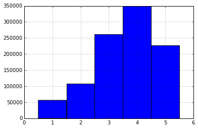

```python
data.rating.hist(bins=5, align='left', range=[1, 6])
```

### Question 4

Afficher l'histogramme du nombre de notes reçues par chaque film

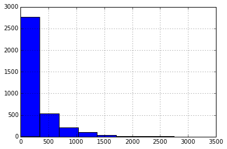

```python
data.groupby('movie_id', axis=0)['rating'].count().hist(bins=10)
```

### Question 5

Afficher l'histogramme des notes moyennes des films.

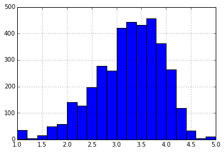

```python
data.groupby('movie_id', axis=0)['rating'].mean().hist(bins=20)
```

La distribution des notes dépent-elle du sexe?

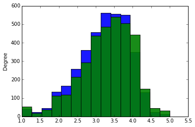

```python
data[data.gender == 'M'].groupby('movie_id', axis=0)['rating'].mean().plot(kind='hist', alpha=0.9, color='b', bins=15)
data[data.gender == 'F'].groupby('movie_id', axis=0)['rating'].mean().plot(kind='hist', alpha=0.9, color='g', bins=15)
```

### Question 6

Afficher l'histogramme des notes des films qui ont été notés plus de seuil_pop = 30 fois.

```python
data.head(3)
```

|  | user_id | movie_id | rating | timestamp | gender | age | occupation | zip | title | genres |
| --- | --- | --- | --- | --- | --- | --- | --- | --- | --- | --- |
| 0 | 1 | 1193 | 5 | 978300760 | F | 1 | 10 | 48067 | One Flew Over the Cuckoo's Nest (1975) | Drama |
| 1 | 2 | 1193 | 5 | 978298413 | M | 56 | 16 | 70072 | One Flew Over the Cuckoo's Nest (1975) | Drama |
| 2 | 12 | 1193 | 4 | 978220179 | M | 25 | 12 | 32793 | One Flew Over the Cuckoo's Nest (1975) | Drama |

```python
map_id_to_count = data.groupby('movie_id')['rating'].count().to_dict()
data['movie_count'] = data['movie_id'].map(map_id_to_count)   # rajoute une variable comptant le nombre de votes par film
```

```python
data.head(3)
```

|  | user_id | movie_id | rating | timestamp | gender | age | occupation | zip | title | genres | movie_count |
| --- | --- | --- | --- | --- | --- | --- | --- | --- | --- | --- | --- |
| 0 | 1 | 1193 | 5 | 978300760 | F | 1 | 10 | 48067 | One Flew Over the Cuckoo's Nest (1975) | Drama | 1725 |
| 1 | 2 | 1193 | 5 | 978298413 | M | 56 | 16 | 70072 | One Flew Over the Cuckoo's Nest (1975) | Drama | 1725 |
| 2 | 12 | 1193 | 4 | 978220179 | M | 25 | 12 | 32793 | One Flew Over the Cuckoo's Nest (1975) | Drama | 1725 |

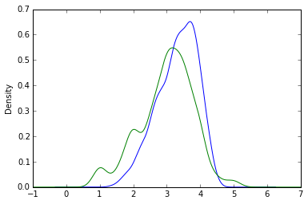

```python
# changer kde par hist pour retrouver un histogramme et non une estimation de la densite
data[data.movie_count >= seuil_pop].groupby('movie_id', axis=0)['rating'].mean().plot(kind='kde', color='b')
data[data.movie_count <= seuil_pop].groupby('movie_id', axis=0)['rating'].mean().plot(kind='kde', color='g')
```

### Question 7

Afficher un "scatter plot" des notes moyennes pour les hommes contre les notes des femmes pour chaque film (notés plus de seuil_pop = 100 fois).

```python
seuil_pop = 100
data_popular = data[data.movie_count >= seuil_pop]
mean_ratings = data_popular.pivot_table(values='rating', index='title',
                                columns='gender', aggfunc='mean')
```

```python
mean_ratings.sort('F', ascending=False).head(10) #top 10 féminin
```

| gender title | F | M |
| --- | --- | --- |
| Close Shave, A (1995) | 4.644444 | 4.473795 |
| Wrong Trousers, The (1993) | 4.588235 | 4.478261 |
| General, The (1927) | 4.575758 | 4.329480 |
| Sunset Blvd. (a.k.a. Sunset Boulevard) (1950) | 4.572650 | 4.464589 |
| Wallace & Gromit: The Best of Aardman Animation (1996) | 4.563107 | 4.385075 |
| Schindler's List (1993) | 4.562602 | 4.491415 |
| Grand Illusion (Grande illusion, La) (1937) | 4.560976 | 4.266129 |
| Shawshank Redemption, The (1994) | 4.539075 | 4.560625 |
| Grand Day Out, A (1992) | 4.537879 | 4.293255 |
| To Kill a Mockingbird (1962) | 4.536667 | 4.372611 |

```python
mean_ratings.sort('M', ascending=False).head(10) #top 10 masculin
```

| gender title | F | M |
| --- | --- | --- |
| Godfather, The (1972) | 4.314700 | 4.583333 |
| Seven Samurai (The Magnificent Seven) (Shichinin no samurai) (1954) | 4.481132 | 4.576628 |
| Shawshank Redemption, The (1994) | 4.539075 | 4.560625 |
| Raiders of the Lost Ark (1981) | 4.332168 | 4.520597 |
| Usual Suspects, The (1995) | 4.513317 | 4.518248 |
| Star Wars: Episode IV - A New Hope (1977) | 4.302937 | 4.495307 |
| Schindler's List (1993) | 4.562602 | 4.491415 |
| Paths of Glory (1957) | 4.392857 | 4.485149 |
| Wrong Trousers, The (1993) | 4.588235 | 4.478261 |
| Close Shave, A (1995) | 4.644444 | 4.473795 |

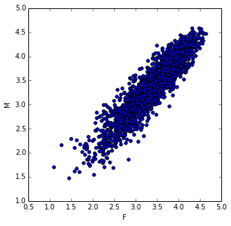

```python
mean_ratings.plot(x='F', y='M', kind='scatter', figsize=(5,5))
```

### Question 8

Afficher un "scatter plot" des notes moyennes des hommes vs les femmes pour chaque film noté moins de seuil_pop = 100 fois.

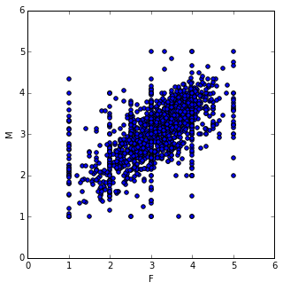

```python
data_not_popular = data[data.movie_count <= seuil_pop]
mean_ratings_not_popular = data_not_popular.pivot_table(values='rating', index='title',
                                columns='gender', aggfunc='mean')
mean_ratings_not_popular.plot(x='F', y='M', kind='scatter', figsize=(5,5))
```

### Questions ouvertes

Quel disparité de comportement observe-t-on entre les hommes et les femmes d’après la dernière figure?